# Visit Scotland Final Project

### Data visualisations for presentation

Transport

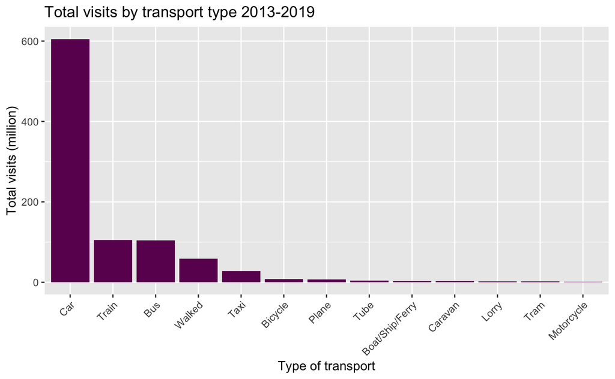

```r
# "Is there a particular method of travel our visitors arrive by?".

transport %>%
  filter(breakdown_of_domestic_tourism == "Visits" & travel_type != "Other") %>%
  group_by(travel_type) %>%
  summarise(total_visits = sum(value)) %>%
  ggplot(aes(x = reorder(travel_type, -total_visits), y = total_visits, fill = "blue")) +
  geom_col() +
  theme(axis.text.x = element_text(angle = 45, hjust = 1),
        legend.position = "none") +
  labs(x = "Type of transport",
       y = "Total visits (million)",
       title = "Total visits by transport type 2013-2019") +
  scale_fill_manual(values = "#6B085E")
```

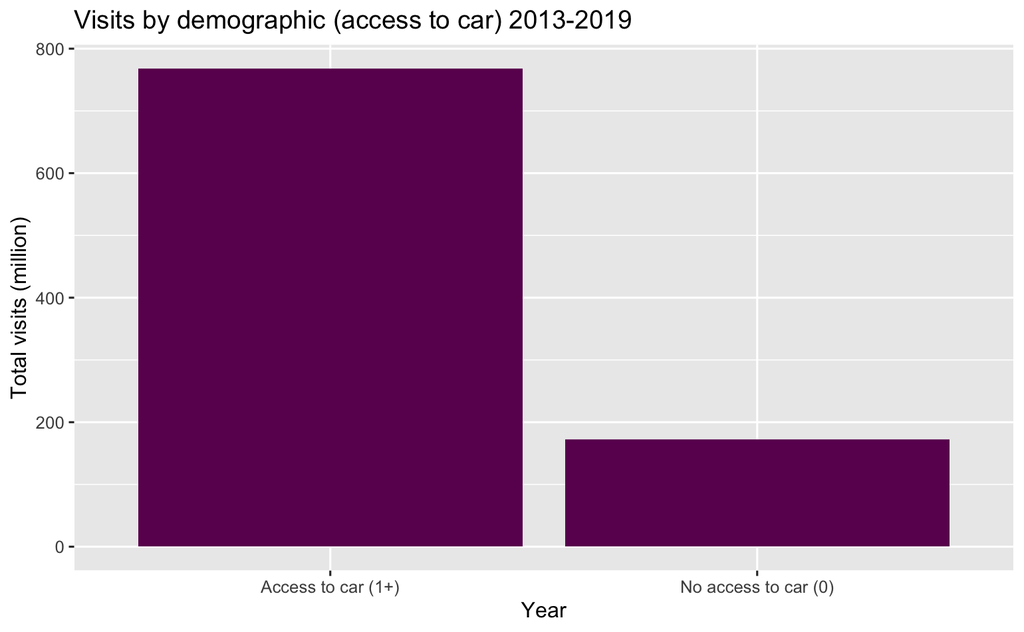

```r
demographics %>%
  filter(access_to_car != "All" & breakdown_of_domestic_tourism == "Visits") %>%
  group_by(access_to_car) %>%
  summarise(total_car = sum(value)) %>%
  ggplot(aes(x = access_to_car, y = total_car, fill = "blue")) +
  geom_col() +
  theme(legend.position = "none") +
  labs(x = "Year",
       y = "Total visits (million)",
       title = "Visits by demographic (access to car) 2013-2019",
       fill = "Access to car") +
  scale_fill_manual(values = "#6B085E")
```

Locations

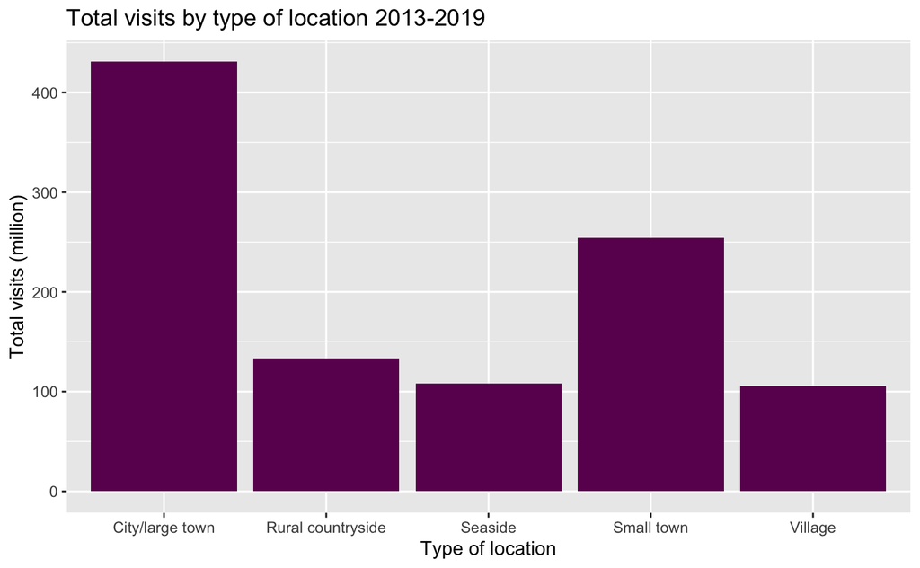

```r
# "what type of locations receive the most visits?"

location %>%
  filter(breakdown_of_domestic_tourism == "Visits"
         & type_of_location_visited != "Other") %>%
  group_by(type_of_location_visited) %>%
  summarise(total_visits = sum(value)) %>%
  ggplot(aes(x = type_of_location_visited, y = total_visits, fill = "blue")) +
  geom_col() +
  theme(legend.position = "none") +
  labs(x = "Type of location",
       y = "Total visits (million)",
       title = "Total visits by type of location 2013-2019") +
  scale_fill_manual(values = "#6B085E")
```

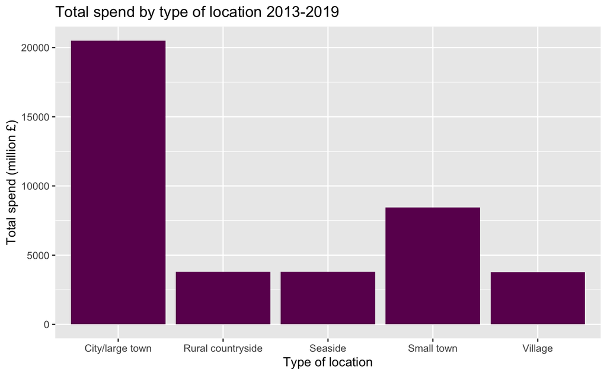

```r
# "what kinds of locations do people spend the most in?"
location %>%
  filter(breakdown_of_domestic_tourism == "Expenditure"
         & type_of_location_visited != "Other") %>%
  group_by(type_of_location_visited) %>%
  summarise(total_visits = sum(value)) %>%
  ggplot(aes(x = type_of_location_visited, y = total_visits, fill = "blue")) +
  geom_col() +
  theme(legend.position = "none") +
  labs(x = "Type of location",
       y = "Total spend (million £)",
       title = "Total spend by type of location 2013-2019") +
  scale_fill_manual(values = "#6B085E")
```

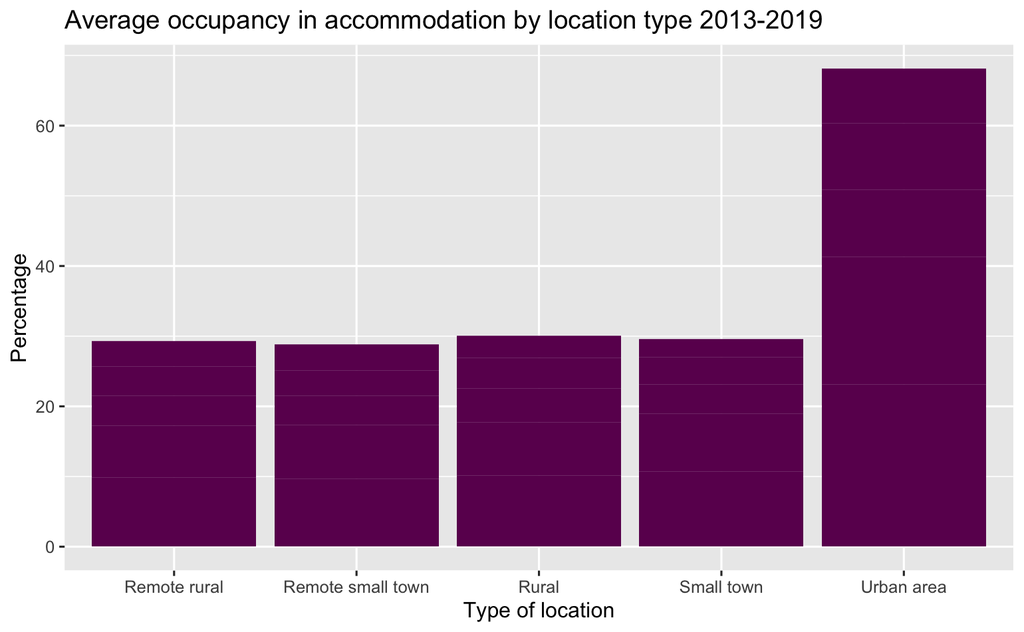

```r
accomodation %>%
  filter(location != "Other") %>%
  group_by(location, accommodation_type) %>%
  summarise(popular_accomodation = sum(value)/100) %>%
  arrange(desc(popular_accomodation)) %>%
  ggplot(aes(x = location, y = popular_accomodation, fill = "blue")) +
  geom_col() +
  theme(legend.position = "none") +
  labs(x = "Type of location",
       y = "Percentage",
       title = "Average occupancy in accommodation by location type 2013-2019") +
  scale_fill_manual(values = "#6B085E")
```

Accommodation

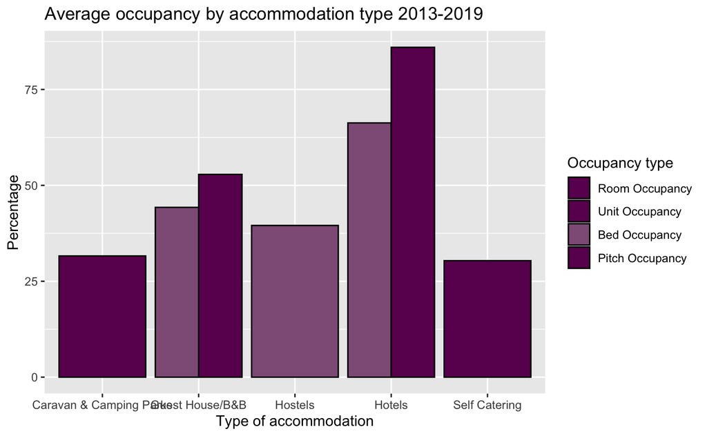

```r
# "What type of accomodation is most popular?"
accomodation %>%
  group_by(accommodation_type, occupancy_type) %>%
  summarise(popular_accomodation = sum(value)/100) %>%
  ggplot(aes(x = accommodation_type, y = popular_accomodation, fill = occupancy_type)) +
  geom_col(position = "dodge", color = "black") +
  labs(x = "Type of accommodation",
       y = "Percentage",
       title = "Average occupancy by accommodation type 2013-2019",
       fill = "Occupancy type") +
  scale_fill_manual(values = c("Room Occupancy" = "#6B085E",
                               "Unit Occupancy" = "#6B085E",
                               "Bed Occupancy" = "#905E88",
                               "Pitch Occupancy" = "#6B085E"))
```

```r
NA
```

2012-2019; hotel is by far the highest.

2019 data, from location set. When breaking down by location (as above), an interesting finding is that in the urban area, B&B’s are just as popular as hotels. Maybe down to a certain B&B site?

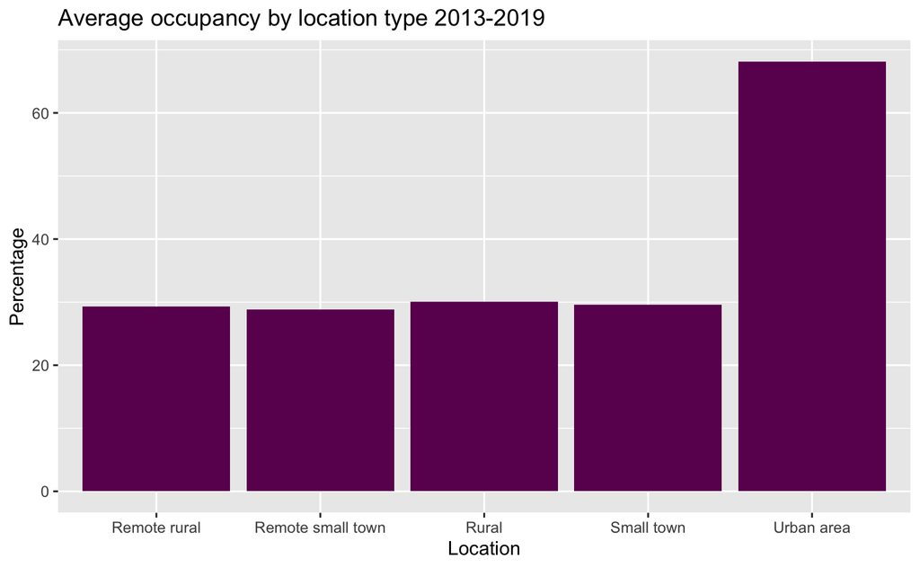

```r
# trying to figure out the correct way of displaying the accommodation data
accomodation %>%
  filter(location != "Other") %>%
  group_by(location) %>%
  summarise(popular_accomodation = sum(value)/100) %>%
  ggplot(aes(x = location, y = popular_accomodation, fill = "blue")) +
  geom_col(position = "dodge") +
  theme(legend.position = "none") +
  labs(x = "Location",
       y = "Percentage",
       title = "Average occupancy by location type 2013-2019") +
  scale_fill_manual(values = "#6B085E")
```

Breaking the accommodation down by area, the most popular location type is urban areas.

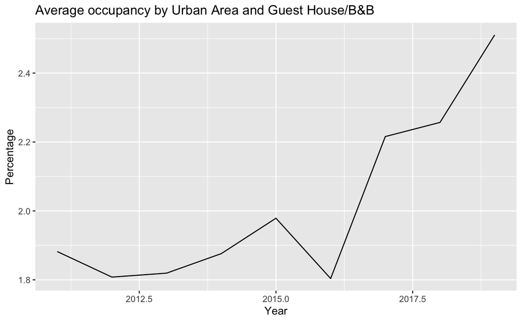

```r
accomodation %>%
  filter(location == "Urban area" & accommodation_type == "Guest House/B&B") %>%
  group_by(year) %>%
  summarise(popular_accomodation = sum(value)/100) %>%
  ggplot(aes(x = year, y = popular_accomodation)) +
  geom_line() +
  labs(x = "Year",
       y = "Percentage",
       title = "Average occupancy by Urban Area and Guest House/B&B")
```

Activities

```r
# What kind of tourism activity generates the highest income?
activities %>%
  filter(breakdown_of_domestic_tourism == "Expenditure" & activity_type != "Other") %>%
  group_by(activity_type) %>%
  summarise(highest_income = sum(value)) %>%
  ggplot(aes(x = reorder(activity_type, -highest_income), y = highest_income, fill = "blue")) +
  geom_col() +
  theme(axis.text.x = element_text(angle = 45, hjust = 1),
        legend.position = "none") +
  labs(x = "Type of activity",
       y = "Sum of spend (million £)",
       title = "Total spend by activity type 2013-2019") +
  scale_fill_manual(values = "#6B085E")
```

[output not shown]

2013-2019, sum of value in million pounds. Highest is eating out (with shopping and visiting family/friends following)

```r
# Which kind of activity generates the most visits?
activities %>%
  filter(breakdown_of_domestic_tourism == "Visits" & activity_type != "Other") %>%
  group_by(activity_type) %>%
  summarise(highest_income = sum(value)) %>%
  ggplot(aes(x = reorder(activity_type, -highest_income), y = highest_income, fill = "blue")) +
  geom_col() +
  theme(axis.text.x = element_text(angle = 45, hjust = 1),
        legend.position = "none") +
  labs(x = "Type of activity",
       y = "Visits (million)",
       title = "Total visits by activity type 2013-2019") +
  scale_fill_manual(values = "#6B085E")
```

[output not shown]

2013-2019, sum of million visits. Highest is visits with family/friends. Eating out coming in second, and outdoor leisure in third.

Demographics

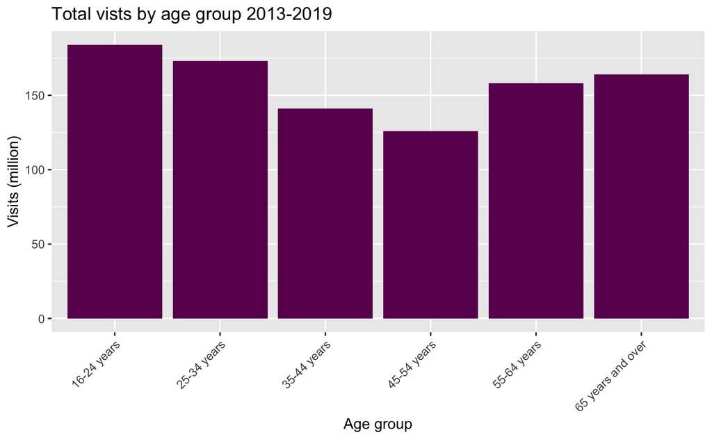

```r
# Is there a particular key demographic of visitors we should be focusing on?

demographics %>%
  filter(age != "All" & breakdown_of_domestic_tourism == "Visits") %>%
  group_by(age) %>%
  summarise(most_visits = sum(value)) %>%
  ggplot(aes(x = age, y = most_visits, fill = "blue")) +
  geom_col() +
  theme(axis.text.x = element_text(angle = 45, hjust = 1),
        legend.position = "none") +
  labs(x = "Age group",
       y = "Visits (million)",
       title = "Total vists by age group 2013-2019") +
  scale_fill_manual(values = "#6B085E")
```

Yes, and no. The data from this dataset isn’t great for analysis, because a lot of inferences have to be drawn. A key insight to be drawn from this is to complete further research / get better data.

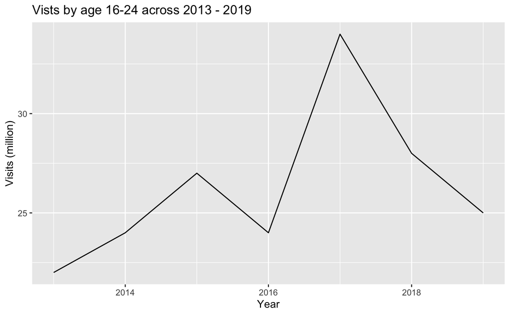

```r
# breaking the age group by year
demographics %>%
  filter(age == "16-24 years" & breakdown_of_domestic_tourism == "Visits") %>%
  ggplot(aes(x = year, y = value)) +
  geom_line() +
  labs(x = "Year",
       y = "Visits (million)",
       title = "Vists by age 16-24 across 2013 - 2019")
```

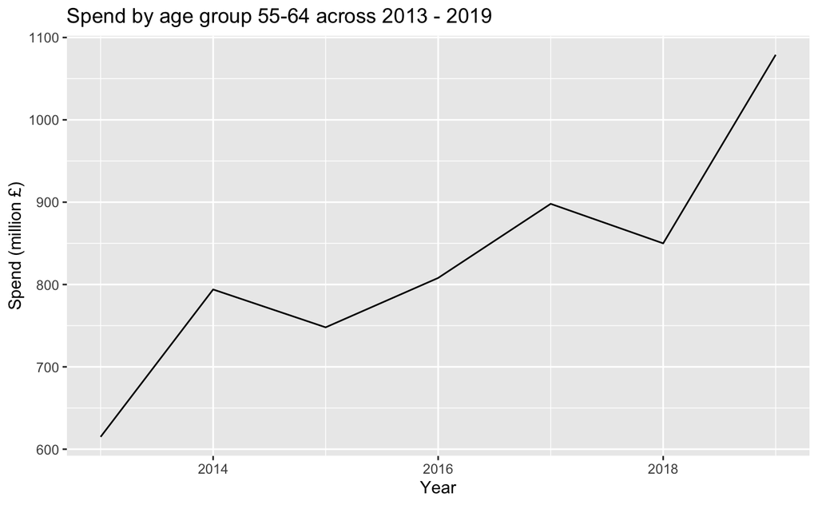

```r
demographics %>%
  filter(age == "55-64 years" & breakdown_of_domestic_tourism == "Expenditure") %>%
  ggplot(aes(x = year, y = value)) +
  geom_line() +
  labs(x = "Year",
       y = "Spend (million £)",
       title = "Spend by age group 55-64 across 2013 - 2019")
```

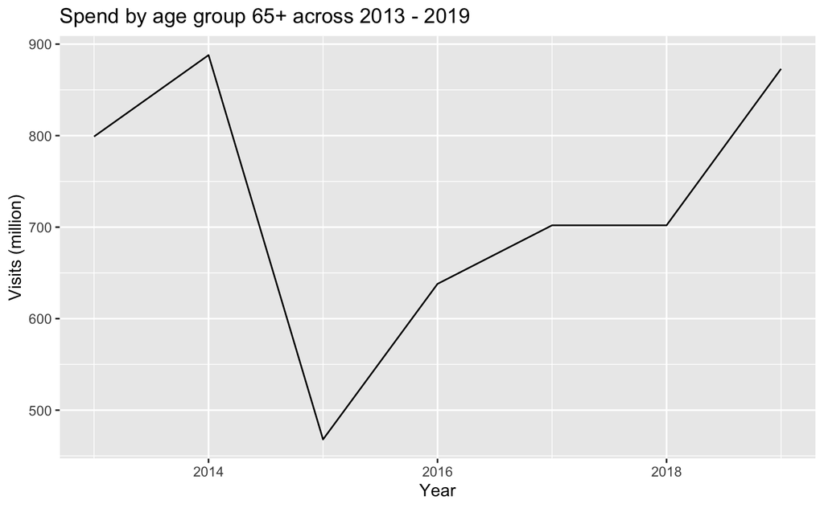

```r
demographics %>%
  filter(age == "65 years and over" & breakdown_of_domestic_tourism == "Expenditure") %>%
  ggplot(aes(x = year, y = value)) +
  geom_line() +
  labs(x = "Year",
       y = "Visits (million)",
       title = "Spend by age group 65+ across 2013 - 2019")
```

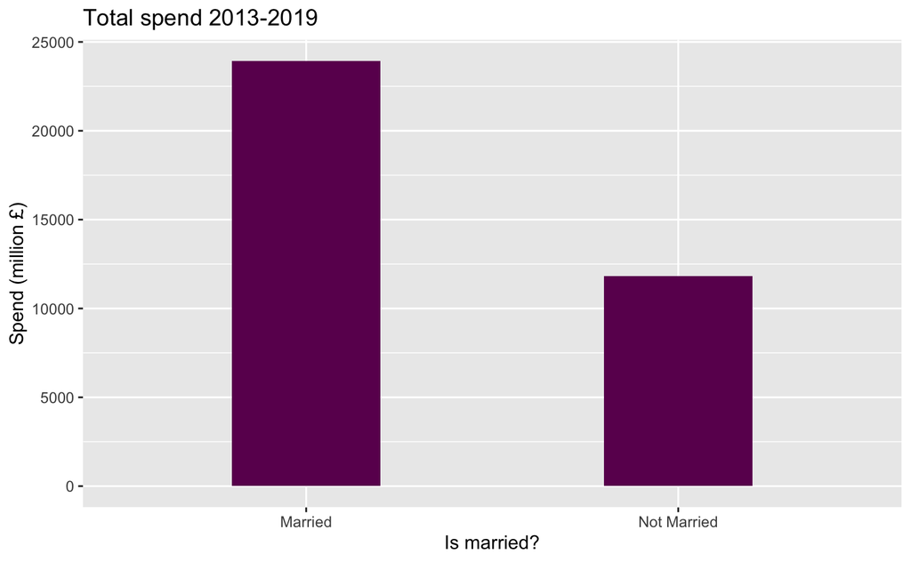

```r
# Who spends the most?
demographics %>%
  filter(breakdown_of_domestic_tourism == "Expenditure" & marital_status != "All") %>%
  group_by(marital_status) %>%
  summarise(highest_spend = sum(value)) %>%
  ggplot(aes(x = marital_status, y = highest_spend, fill = "blue")) +
  geom_col(width = 0.4) +
  theme(legend.position = "none") +
  labs(x = "Is married?",
       y = "Spend (million £)",
       title = "Total spend 2013-2019") +
  scale_fill_manual(values = "#6B085E")
```

This is where the data is limited, because the survey / options for respondents was limited, so marital_status can’t really be fairly compared. However, going by the data strictly (because this does still reflect something, and even when grouping age so that they could be compared, the “married” response comes out higher).

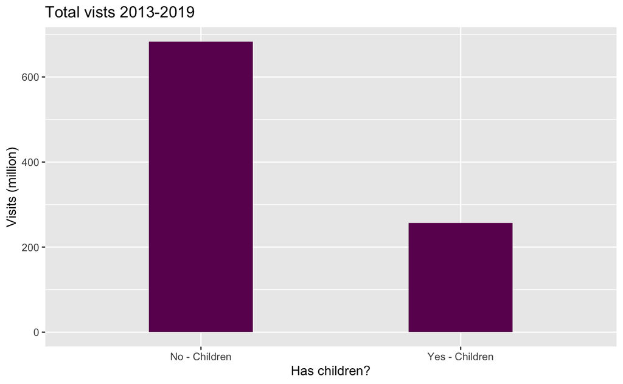

```r
# Who visits the most?
demographics %>%
  filter(breakdown_of_domestic_tourism == "Visits" & children != "All") %>%
  group_by(children) %>%
  summarise(most_visits = sum(value)) %>%
  ggplot(aes(x = children, y = most_visits, fill = "blue")) +
  geom_col(width = 0.4) +
  theme(legend.position = "none") +
  labs(x = "Has children?",
       y = "Visits (million)",
       title = "Total vists 2013-2019") +
  scale_fill_manual(values = "#6B085E")
```

This is the same issue, but also response / relevance, as the above.

Regional demographics

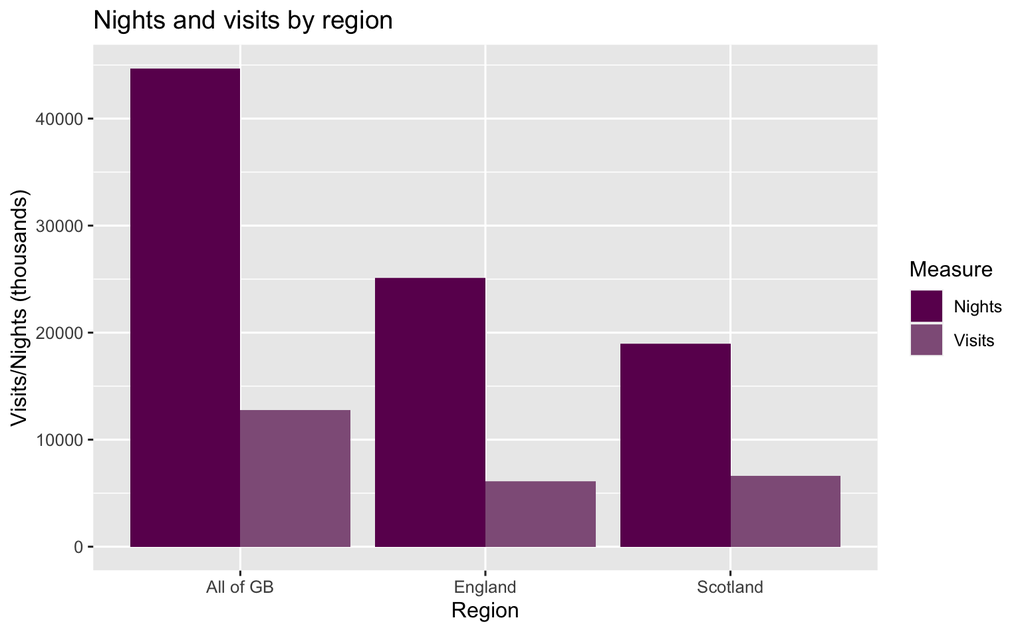

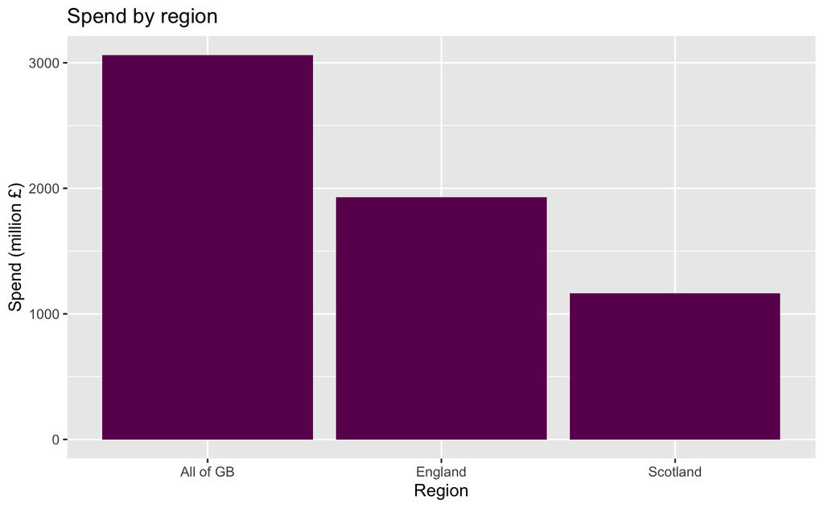

Change over time

```r
# How have general tourism rates changed over time?

transport %>%
  filter(breakdown_of_domestic_tourism == "Visits") %>%
  group_by(year) %>%
  summarise(total_year = sum(value)) %>%
  ggplot(aes(x = year, y = total_year)) +
  geom_line() +
  theme(legend.position = "none") +
  labs(x = "Year",
       y = "Sum of visits (millions)",
       title = "Tourism rates (by transport, visits) 2013-2019")

demographics %>%
  filter(breakdown_of_domestic_tourism == "Expenditure") %>%
  group_by(year) %>%
  summarise(total_year = sum(value)) %>%
  ggplot(aes(x = year, y = total_year)) +
  geom_line() +
  theme(legend.position = "none") +
  labs(x = "Year",
       y = "Sum of spend (million £)",
       title = "Tourism rates (by demographics, spend) 2013-2019")
```

[output not shown]

The *general* picture over time, is that for visits, it increases until 2017, and then declines (some more than others). For expenditure, it increases until 2017, declines in 2018, and increases again in 2019.

Predicting change This has been plotted in python. The model was inaccurate. I also tried to clean/wrangle the data so that I could plot it in R, but this didn’t work either.

### Summary and descriptive statistics for the presentation

Transport slides

```r
# total transport visits who use other types of transportation
transport %>%
  filter(breakdown_of_domestic_tourism == "Visits" & travel_type != "Other") %>%
  summarise(total_value = sum(value))

# total transport visits who use car
transport %>%
  filter(breakdown_of_domestic_tourism == "Visits" & travel_type == "Car") %>%
  summarise(total_value = sum(value))
```

605.3/930.9 65%

```r
# total from visits who report having access to a car
demographics %>%
  filter(access_to_car == "Access to car (1+)" & breakdown_of_domestic_tourism == "Visits") %>%
  summarise(total_value = sum(value))

# total from visits
demographics %>%
  filter(access_to_car != "All" & breakdown_of_domestic_tourism == "Visits") %>%
  summarise(total_value = sum(value))
```

768/940 81.7% report having access to a car

Location slides

```r
# total who visit city/large town
location %>%
  filter(breakdown_of_domestic_tourism == "Visits" & type_of_location_visited == "City/large town") %>%
  summarise(total_value = sum(value))

# total who visit (by location)
location %>%
  filter(breakdown_of_domestic_tourism == "Visits" & type_of_location_visited != "Other") %>%
  summarise(total_value = sum(value))
```

431/1032 41.7%

[output not shown]

68%

Accommodation slides

```r
# average accommodation occupancy
accomodation %>%
  group_by(accommodation_type, occupancy_type) %>%
  summarise(popular_accomodation = sum(value)/100)
```

| accommodation_type | occupancy_type | popular_accomodation |
| --- | --- | --- |
| Caravan & Camping Parks | Pitch Occupancy | 31.5960 |
| Guest House/B&B | Bed Occupancy | 44.2659 |
| Guest House/B&B | Room Occupancy | 52.8553 |
| Hostels | Bed Occupancy | 39.5446 |
| Hotels | Bed Occupancy | 66.2745 |
| Hotels | Room Occupancy | 85.9898 |
| Self Catering | Unit Occupancy | 30.3677 |

Accommodation slides

```r
# average accommodation occupancy in urban areas
accomodation %>%
  filter(location == "Urban area") %>%
  summarise(popular_accomodation = sum(value)/100)
```

Other point is urban B&B increasing.

Demographics slides

```r
# sum of expenditure by is_married
demographics %>%
  filter(breakdown_of_domestic_tourism == "Expenditure" & marital_status == "Married") %>%
  summarise(popular_accomodation = sum(value))
# 23928 (million)

# sum of expenditure
demographics %>%
  filter(breakdown_of_domestic_tourism == "Expenditure" & marital_status != "All") %>%
  summarise(popular_accomodation = sum(value))
# 35751
```

23928/35751 Married - 66.9% spend

Demographics

```r
# sum of visits by have_children = no
demographics %>%
  filter(breakdown_of_domestic_tourism == "Visits" & children == "No - Children") %>%
  summarise(popular_accomodation = sum(value))
683

# sum visits
demographics %>%
  filter(breakdown_of_domestic_tourism == "Visits" & children != "All") %>%
  summarise(popular_accomodation = sum(value))
940
```

683/940 - 72%

Demographics slides - age

```r
# 16-24 year old - sum of visits
demographics %>%
  filter(breakdown_of_domestic_tourism == "Visits" & age == "16-24 years") %>%
  summarise(popular_accomodation = sum(value))

# sum of visits (all age groups)
demographics %>%
  filter(breakdown_of_domestic_tourism == "Visits" & age != "All") %>%
  summarise(popular_accomodation = sum(value))
```

184/946 - 19.4%

Demographics slides - Older age groups

```r
# sum of spend of 55-64 year olds
demographics %>%
  filter(breakdown_of_domestic_tourism == "Expenditure" & age == "55-64 years") %>%
  summarise(total = sum(value))
5792

# sum of spend 65+
demographics %>%
  filter(breakdown_of_domestic_tourism == "Expenditure" & age == "65 years and over") %>%
  summarise(total = sum(value))
5070
```

5070+5792 - 10862 total

[output not shown]

16-24 - 184 55-64 - 158 65+ - 164

Regional demographics

```r
# total visits where region is england
regional_domestic %>%
  filter(breakdown_of_domestic_tourism == "Visits" & region_of_residence == "England") %>%
  summarise(total = sum(value))

# total visits where region is scotland
regional_domestic %>%
  filter(breakdown_of_domestic_tourism == "Visits" & region_of_residence == "Scotland") %>%
  summarise(total = sum(value))
```

England - 109680 Scotland - 112132 Difference is 2452

Note; haven’t used this number.

Activities

```r
# total spend of eating out activity
activities %>%
  filter(breakdown_of_domestic_tourism == "Expenditure" & activity_type == "Eating out") %>%
  summarise(total = sum(value))

# total spend of all activities
activities %>%
  filter(breakdown_of_domestic_tourism == "Expenditure" & activity_type != "Other") %>%
  summarise(total = sum(value))
```

13409/75277

Eating out accounts for 13409 million (17.8%)

```r
# sum of visits for 'visit family/friends' activity
activities %>%
  filter(breakdown_of_domestic_tourism == "Visits" & activity_type == "Visit family/friends") %>%
  summarise(total = sum(value))

# sum of visits for all activities
activities %>%
  filter(breakdown_of_domestic_tourism == "Visits" & activity_type != "Other") %>%
  summarise(total = sum(value))
```

315/1694

Visiting family/friends 315 million – 18.5%

### Notes on VisitScotland updating their data

Following the challenges with data modelling, I completed further research on VisitScotland’s site. They also complete another piece of research, called the Great Britain Tourism Survey. They have noted (https://www.visitscotland.org/binaries/content/assets/dot-org/pdf/research-papers-2/uk-visitors/gbts-gbdvs-update-nov21.pdf) that from 2020 onwards, they will be changing the structure of the data. It seems that they have found the same issues as myself, and are putting similar changes to the ones I recommend in place.

However, there is no data available yet, as travel has been severely impacted due to Covid.

https://www.visitscotland.org/binaries/content/assets/dot-org/pdf/research-papers-2/uk-visitors/gbts-gbdvs-update-nov21.pdf

### Main recommendations:

From my analysis and insights, I have recommended that VisitScotland can be confident that the majority of their customers travel by and have access to car, so any promotions that they may have planned which involve remote locations, they can confidently proceed with. I recommended that VisitScotland develop partnerships with B&B providers, particularly in urban areas, which is an area that they should focus on. In terms of profiling a demographic, the age group of 55+ is the age group I recommend to target. The key takeaway from my analysis however, is to restructure their data collection, as there were shortcomings in two datasets which made analysis a challenge. I also recommended that they collect data more frequently, e.g. monthly, as this would allow for predictive models to be built, which is not currently possible.